# PS6

Justin Post

2023-09-28

## Exercises from *Advanced R*

Exercise 3 from section 11.1.2.

Use both a `for` loop and `lapply()` to fit linear modesl to the `mtcars` data frame using the formulas stored in this list:

```r
formulas <- list(
  mpg ~ disp,
  mpg ~ I(1/disp),
  mpg ~ disp + wt,
  mpg ~ I(1/disp) + wt
)
```

First, let’s learn a bit about fitting a basic linear model (multiple linear regression) in R. This can be done with the `lm()` function.

```r
fit <- lm(mpg ~ disp, data = mtcars)
```

We can obtain a summary of the model fit using `summary()`.

```r
summary(fit)
```

```
##
## Call:
## lm(formula = mpg ~ disp, data = mtcars)
##
## Residuals:
##     Min      1Q  Median      3Q     Max
## -4.8922 -2.2022 -0.9631  1.6272  7.2305
##
## Coefficients:
##              Estimate Std. Error t value Pr(>|t|)
## (Intercept) 29.599855   1.229720  24.070  < 2e-16 ***
## disp        -0.041215   0.004712  -8.747 9.38e-10 ***
## ---
## Signif. codes:  0 '***' 0.001 '**' 0.01 '*' 0.05 '.' 0.1 ' ' 1
##
## Residual standard error: 3.251 on 30 degrees of freedom
## Multiple R-squared:  0.7183, Adjusted R-squared:  0.709
## F-statistic: 76.51 on 1 and 30 DF,  p-value: 9.38e-10
```

We can obtain diagnostic plots (for checking assumptions about the model) using the generic `plot()` function. This actually calls `plot.lm()` (see `methods(plot)`, which leads to `getAnywhere("plot.lm")` to get the source code for this method!).

```r
class(fit)
```

```
## [1] "lm"
```

```r
str(fit, max.level = 1)
```

```
## List of 12
##  $ coefficients : Named num [1:2] 29.5999 -0.0412
##   ..- attr(*, "names")= chr [1:2] "(Intercept)" "disp"
##  $ residuals    : Named num [1:32] -2.01 -2.01 -2.35 2.43 3.94 ...
##   ..- attr(*, "names")= chr [1:32] "Mazda RX4" "Mazda RX4 Wag" "Datsun 710" "Hornet 4 Drive" ...
##  $ effects      : Named num [1:32] -113.65 -28.44 -1.79 2.65 3.92 ...
##   ..- attr(*, "names")= chr [1:32] "(Intercept)" "disp" "" "" ...
##  $ rank         : int 2
##  $ fitted.values: Named num [1:32] 23 23 25.1 19 14.8 ...
##   ..- attr(*, "names")= chr [1:32] "Mazda RX4" "Mazda RX4 Wag" "Datsun 710" "Hornet 4 Drive" ...
##  $ assign       : int [1:2] 0 1
##  $ qr           :List of 5
##   ..- attr(*, "class")= chr "qr"
##  $ df.residual  : int 30
##  $ xlevels      : Named list()
##  $ call         : language lm(formula = mpg ~ disp, data = mtcars)
##  $ terms        :Classes 'terms', 'formula'  language mpg ~ disp
##   .. ..- attr(*, "variables")= language list(mpg, disp)
##   .. ..- attr(*, "factors")= int [1:2, 1] 0 1
##   .. .. ..- attr(*, "dimnames")=List of 2
##   .. ..- attr(*, "term.labels")= chr "disp"
##   .. ..- attr(*, "order")= int 1
##   .. ..- attr(*, "intercept")= int 1
##   .. ..- attr(*, "response")= int 1
##   .. ..- attr(*, ".Environment")=<environment: R_GlobalEnv>
##   .. ..- attr(*, "predvars")= language list(mpg, disp)
##   .. ..- attr(*, "dataClasses")= Named chr [1:2] "numeric" "numeric"
##   .. .. ..- attr(*, "names")= chr [1:2] "mpg" "disp"
##  $ model        :'data.frame':   32 obs. of  2 variables:
##   ..- attr(*, "terms")=Classes 'terms', 'formula'  language mpg ~ disp
##   .. .. ..- attr(*, "variables")= language list(mpg, disp)
##   .. .. ..- attr(*, "factors")= int [1:2, 1] 0 1
##   .. .. .. ..- attr(*, "dimnames")=List of 2
##   .. .. ..- attr(*, "term.labels")= chr "disp"
##   .. .. ..- attr(*, "order")= int 1
##   .. .. ..- attr(*, "intercept")= int 1
##   .. .. ..- attr(*, "response")= int 1
##   .. .. ..- attr(*, ".Environment")=<environment: R_GlobalEnv>
##   .. .. ..- attr(*, "predvars")= language list(mpg, disp)
##   .. .. ..- attr(*, "dataClasses")= Named chr [1:2] "numeric" "numeric"
##   .. .. .. ..- attr(*, "names")= chr [1:2] "mpg" "disp"
##  - attr(*, "class")= chr "lm"
```

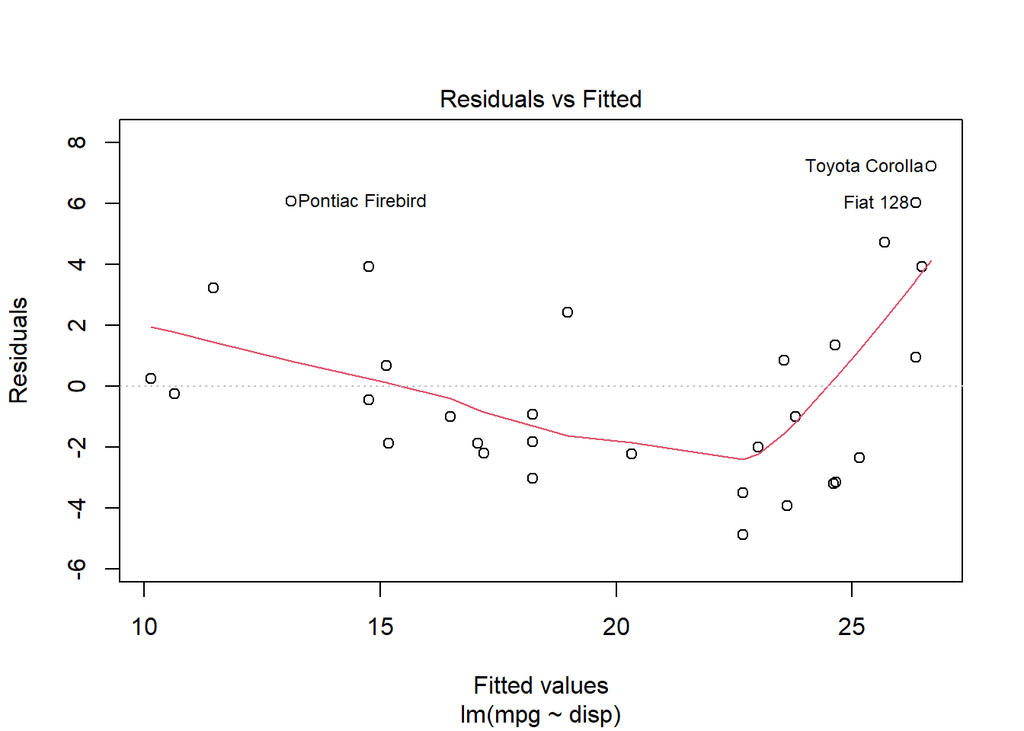

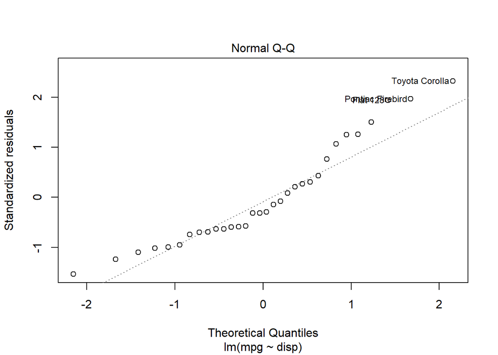

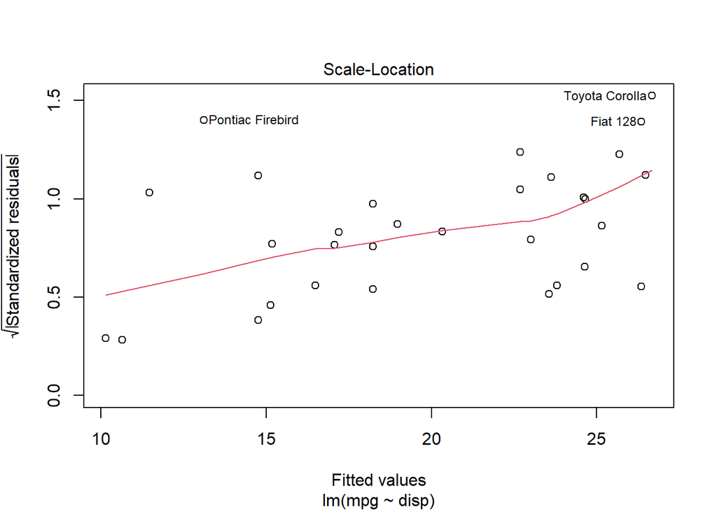

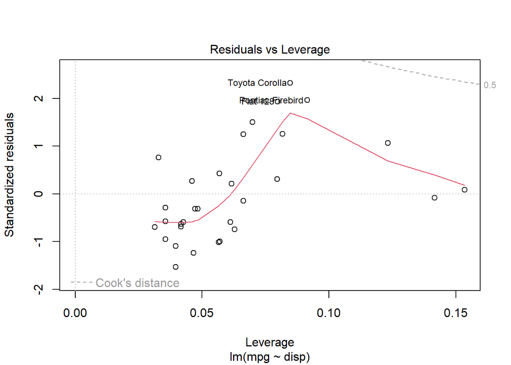

```r
plot(fit)
```

If we wanted to get a scatter plot with the fitted line overlayed. We can do that using `Base R` or the `tidyverse`.

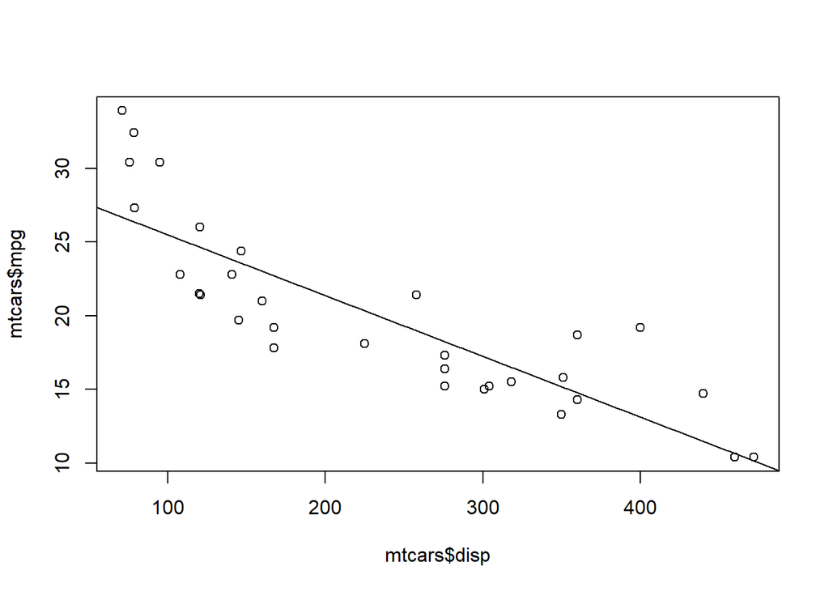

```r
plot(x = mtcars$disp, y = mtcars$mpg)
#sequence for plotting the model fit
x <- seq(from = 50, to = 500, by = 0.5)
#predictions come from the generic predict() function (we'll cover all this in topic 3!)
preds <- predict(fit, newdata = data.frame(disp = x))
lines(x = x, y = preds)

library(tidyverse)
```

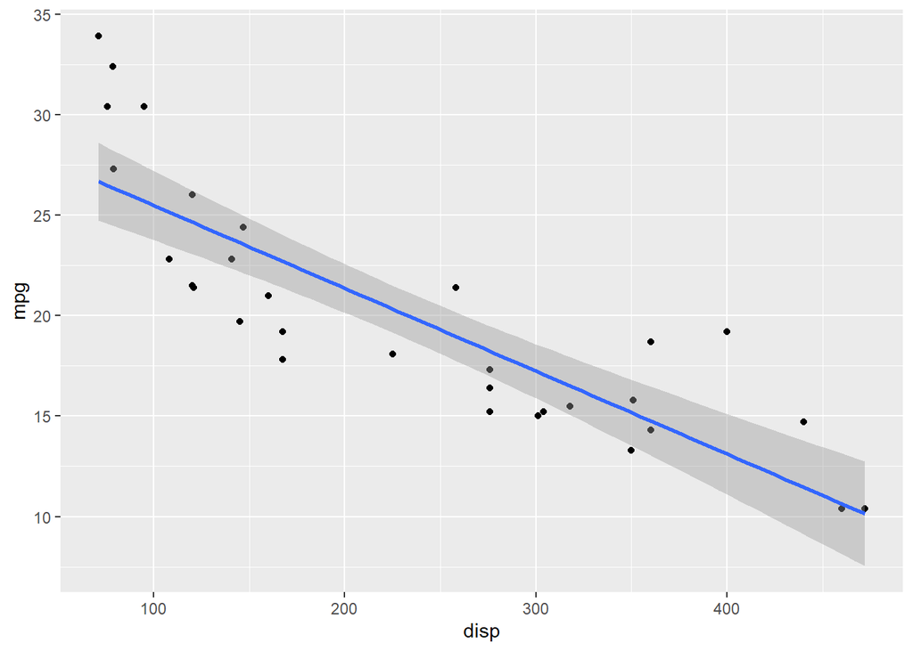

```r
ggplot(mtcars, aes(x = disp, y = mpg)) +
  geom_point() +
  geom_smooth(method = "lm")
```

Now let’s use a `for` loop to fit the model for each formula. Here we could use `seq_along(formulas)` to get an indexing vector. I tend to use the `1:length(formulas)` kind of syntax. (You could also directly iterate over the formulas elements!)

```r
#use a for loop to fit our models
seq_along(formulas)
```

```
## [1] 1 2 3 4
```

```r
for (i in 1:length(formulas)){
  lm(formulas[[i]], data = mtcars) %>%
    summary() %>%
    print()
}
```

```
##
## Call:
## lm(formula = formulas[[i]], data = mtcars)
##
## Residuals:
##     Min      1Q  Median      3Q     Max
## -4.8922 -2.2022 -0.9631  1.6272  7.2305
##
## Coefficients:
##              Estimate Std. Error t value Pr(>|t|)
## (Intercept) 29.599855   1.229720  24.070  < 2e-16 ***
## disp        -0.041215   0.004712  -8.747 9.38e-10 ***
## ---
## Signif. codes:  0 '***' 0.001 '**' 0.01 '*' 0.05 '.' 0.1 ' ' 1
##
## Residual standard error: 3.251 on 30 degrees of freedom
## Multiple R-squared:  0.7183, Adjusted R-squared:  0.709
## F-statistic: 76.51 on 1 and 30 DF,  p-value: 9.38e-10
##
##
## Call:
## lm(formula = formulas[[i]], data = mtcars)
##
## Residuals:
##     Min      1Q  Median      3Q     Max
## -3.7383 -1.8216 -0.0751  1.0487  4.6105
##
## Coefficients:
##              Estimate Std. Error t value Pr(>|t|)
## (Intercept)   10.7520     0.7994   13.45 3.06e-14 ***
## I(1/disp)   1557.6739   114.8935   13.56 2.49e-14 ***
## ---
## Signif. codes:  0 '***' 0.001 '**' 0.01 '*' 0.05 '.' 0.1 ' ' 1
##
## Residual standard error: 2.295 on 30 degrees of freedom
## Multiple R-squared:  0.8597, Adjusted R-squared:  0.855
## F-statistic: 183.8 on 1 and 30 DF,  p-value: 2.494e-14
##
##
## Call:
```

[output cut: 22 more lines]

```
## Residuals:
##     Min      1Q  Median      3Q     Max
## -2.7085 -1.5121 -0.6191  1.5142  4.2314
##
## Coefficients:
##              Estimate Std. Error t value Pr(>|t|)
## (Intercept)   19.0242     3.4520   5.511 6.13e-06 ***
## I(1/disp)   1142.5600   199.8427   5.717 3.47e-06 ***
## wt            -1.7976     0.7327  -2.453   0.0204 *
## ---
## Signif. codes:  0 '***' 0.001 '**' 0.01 '*' 0.05 '.' 0.1 ' ' 1
##
## Residual standard error: 2.124 on 29 degrees of freedom
## Multiple R-squared:  0.8838, Adjusted R-squared:  0.8758
## F-statistic: 110.3 on 2 and 29 DF,  p-value: 2.788e-14
```

```r
#to save the output of the lm() fits, we can initialize a list
fit_list <- list()
for (i in 1:length(formulas)){
  fit_list[[i]] <- lm(formulas[[i]], data = mtcars)
}
```

This is a bit easier using `lapply()`. Note that we pass the name of the function only, `lm`, and not a **call** to the function `lm(x, ...)`. As we have an additional argument to `lm()` other than the formulas, we can pass that as an additional argument to `lapply()`.

```r
#use lapply instead
fit_objects <- lapply(X = formulas, FUN = lm, data = mtcars)
fit_objects[[1]]
```

```
##
## Call:
## FUN(formula = X[[i]], data = ..1)
##
## Coefficients:
## (Intercept)         disp
##    29.59985     -0.04122
```

```r
str(fit_objects, max.level = 1)
```

```
## List of 4
##  $ :List of 12
##   ..- attr(*, "class")= chr "lm"
##  $ :List of 12
##   ..- attr(*, "class")= chr "lm"
##  $ :List of 12
##   ..- attr(*, "class")= chr "lm"
##  $ :List of 12
##   ..- attr(*, "class")= chr "lm"
```

Now let’s fit our models but also pull out some useful stats.

```r
#useful stats to get out
fit
```

```
##
## Call:
## lm(formula = mpg ~ disp, data = mtcars)
##
## Coefficients:
## (Intercept)         disp
##    29.59985     -0.04122
```

```r
sum_fit <- summary(fit)
class(summary(fit))
```

```
## [1] "summary.lm"
```

```r
str(sum_fit)
```

```
## List of 11
##  $ call         : language lm(formula = mpg ~ disp, data = mtcars)
##  $ terms        :Classes 'terms', 'formula'  language mpg ~ disp
##   .. ..- attr(*, "variables")= language list(mpg, disp)
##   .. ..- attr(*, "factors")= int [1:2, 1] 0 1
##   .. .. ..- attr(*, "dimnames")=List of 2
##   .. .. .. ..$ : chr [1:2] "mpg" "disp"
##   .. .. .. ..$ : chr "disp"
##   .. ..- attr(*, "term.labels")= chr "disp"
##   .. ..- attr(*, "order")= int 1
##   .. ..- attr(*, "intercept")= int 1
##   .. ..- attr(*, "response")= int 1
##   .. ..- attr(*, ".Environment")=<environment: R_GlobalEnv>
##   .. ..- attr(*, "predvars")= language list(mpg, disp)
##   .. ..- attr(*, "dataClasses")= Named chr [1:2] "numeric" "numeric"
##   .. .. ..- attr(*, "names")= chr [1:2] "mpg" "disp"
##  $ residuals    : Named num [1:32] -2.01 -2.01 -2.35 2.43 3.94 ...
##   ..- attr(*, "names")= chr [1:32] "Mazda RX4" "Mazda RX4 Wag" "Datsun 710" "Hornet 4 Drive" ...
##  $ coefficients : num [1:2, 1:4] 29.59985 -0.04122 1.22972 0.00471 24.07041 ...
##   ..- attr(*, "dimnames")=List of 2
##   .. ..$ : chr [1:2] "(Intercept)" "disp"
##   .. ..$ : chr [1:4] "Estimate" "Std. Error" "t value" "Pr(>|t|)"
##  $ aliased      : Named logi [1:2] FALSE FALSE
##   ..- attr(*, "names")= chr [1:2] "(Intercept)" "disp"
##  $ sigma        : num 3.25
##  $ df           : int [1:3] 2 30 2
##  $ r.squared    : num 0.718
##  $ adj.r.squared: num 0.709
##  $ fstatistic   : Named num [1:3] 76.5 1 30
##   ..- attr(*, "names")= chr [1:3] "value" "numdf" "dendf"
##  $ cov.unscaled : num [1:2, 1:2] 1.43e-01 -4.85e-04 -4.85e-04 2.10e-06
##   ..- attr(*, "dimnames")=List of 2
##   .. ..$ : chr [1:2] "(Intercept)" "disp"
##   .. ..$ : chr [1:2] "(Intercept)" "disp"
##  - attr(*, "class")= chr "summary.lm"
```

```r
#pull out coefficients
sum_fit$coefficients
```

```
##                Estimate  Std. Error   t value     Pr(>|t|)
## (Intercept) 29.59985476 1.229719515 24.070411 3.576586e-21
## disp        -0.04121512 0.004711833 -8.747152 9.380327e-10
```

```r
str(sum_fit$coefficients)
```

```
##  num [1:2, 1:4] 29.59985 -0.04122 1.22972 0.00471 24.07041 ...
##  - attr(*, "dimnames")=List of 2
##   ..$ : chr [1:2] "(Intercept)" "disp"
##   ..$ : chr [1:4] "Estimate" "Std. Error" "t value" "Pr(>|t|)"
```

```r
dimnames(sum_fit$coefficients)[[1]]
```

```
## [1] "(Intercept)" "disp"
```

```r
#pull out adjusted r squared
sum_fit$adj.r.squared
```

```
## [1] 0.7089548
```

Great, let’s write a custom function to do the fit and to pull out those values. We’ll return them all in a list.

```r
fit_objects <- lapply(X = formulas, FUN = function(x){
  fit <- lm(x, data = mtcars)
  sum_fit <- summary(fit)
  coefs <- sum_fit$coefficients
  adj_r_sq <- sum_fit$adj.r.squared
  list(fit = fit, coefs = coefs, adj_r_sq = adj_r_sq)
})

str(fit_objects[[1]], max.level = 1)
```

```
## List of 3
##  $ fit     :List of 12
##   ..- attr(*, "class")= chr "lm"
##  $ coefs   : num [1:2, 1:4] 29.59985 -0.04122 1.22972 0.00471 24.07041 ...
##   ..- attr(*, "dimnames")=List of 2
##  $ adj_r_sq: num 0.709
```

Alternatively, we can supply a `my_data` argument to our custom function that allows us to pass in a different data frame (as done earlier).

```r
fit_objects <- lapply(X = formulas,
                      FUN = function(x, my_data){
                        fit <- lm(x, data = my_data)
                        sum_fit <- summary(fit)
                        coefs <- sum_fit$coefficients
                        adj_r_sq <- sum_fit$adj.r.squared
                        list(fit = fit, coefs = coefs, adj_r_sq = adj_r_sq)
                      },
                      my_data = mtcars)
```

We could also save our function as an object and call it in a similar manner to how we called `lm()`.

```r
custom_fun <- function(x, my_data){
                        fit <- lm(x, data = my_data)
                        sum_fit <- summary(fit)
                        coefs <- sum_fit$coefficients
                        adj_r_sq <- sum_fit$adj.r.squared
                        list(fit = fit, coefs = coefs, adj_r_sq = adj_r_sq)
                      }

fit_objects <- lapply(X = formulas,
                      FUN = custom_fun,
                      my_data = mtcars)
```

To give an example where we might iterate over a data frame instead, we’ll apply the `lm()` function to each column of the `mtcars` data frame using `mpg` as the response.

```r
#create a matrix of predictors (similar to a data frame)
predictors <- mtcars[, -1]
#use apply to apply a custom function to each column of the data frame
slr_fits <- apply(X = predictors, MARGIN = 2, FUN = function(x1){
  lm(mtcars$mpg ~ x1)
})
```